# NYC Flights - data wrangling II

Author

Published

September 22, 2026

We will again work with data from the `nycflights13` package.

```r
library(nycflights13)
library(tidyverse)
```

## Exercise 1

Examine the documentation for the datasets `airports`, `flights`, and `planes`. What are the dimensions of each? What variables do they have in common that would allow them to be linked together? Note: variables may not be named the same thing in each dataset!

- Airports has 1,458 rows and 8 columns.
- Flights has 336,776 rows and 19 columns.
- Planes has 3,322 rows and 9 columns.
- They have year, tail number, destination, origin

```r
glimpse(airports)
```

```
Rows: 1,458
Columns: 8
$ faa   <chr> "04G", "06A", "06C", "06N", "09J", "0A9", "0G6", "0G7", "0P2", "…
$ name  <chr> "Lansdowne Airport", "Moton Field Municipal Airport", "Schaumbur…
$ lat   <dbl> 41.13047, 32.46057, 41.98934, 41.43191, 31.07447, 36.37122, 41.4…
$ lon   <dbl> -80.61958, -85.68003, -88.10124, -74.39156, -81.42778, -82.17342…
$ alt   <dbl> 1044, 264, 801, 523, 11, 1593, 730, 492, 1000, 108, 409, 875, 10…
$ tz    <dbl> -5, -6, -6, -5, -5, -5, -5, -5, -5, -8, -5, -6, -5, -5, -5, -5, …
$ dst   <chr> "A", "A", "A", "A", "A", "A", "A", "A", "U", "A", "A", "U", "A",…
$ tzone <chr> "America/New_York", "America/Chicago", "America/Chicago", "Ameri…
```

```r
glimpse(flights)
```

```
Rows: 336,776
Columns: 19
$ year           <int> 2013, 2013, 2013, 2013, 2013, 2013, 2013, 2013, 2013, 2…
$ month          <int> 1, 1, 1, 1, 1, 1, 1, 1, 1, 1, 1, 1, 1, 1, 1, 1, 1, 1, 1…
$ day            <int> 1, 1, 1, 1, 1, 1, 1, 1, 1, 1, 1, 1, 1, 1, 1, 1, 1, 1, 1…
$ dep_time       <int> 517, 533, 542, 544, 554, 554, 555, 557, 557, 558, 558, …
$ sched_dep_time <int> 515, 529, 540, 545, 600, 558, 600, 600, 600, 600, 600, …
$ dep_delay      <dbl> 2, 4, 2, -1, -6, -4, -5, -3, -3, -2, -2, -2, -2, -2, -1…
$ arr_time       <int> 830, 850, 923, 1004, 812, 740, 913, 709, 838, 753, 849,…
$ sched_arr_time <int> 819, 830, 850, 1022, 837, 728, 854, 723, 846, 745, 851,…
$ arr_delay      <dbl> 11, 20, 33, -18, -25, 12, 19, -14, -8, 8, -2, -3, 7, -1…
$ carrier        <chr> "UA", "UA", "AA", "B6", "DL", "UA", "B6", "EV", "B6", "…
$ flight         <int> 1545, 1714, 1141, 725, 461, 1696, 507, 5708, 79, 301, 4…
$ tailnum        <chr> "N14228", "N24211", "N619AA", "N804JB", "N668DN", "N394…
$ origin         <chr> "EWR", "LGA", "JFK", "JFK", "LGA", "EWR", "EWR", "LGA",…
$ dest           <chr> "IAH", "IAH", "MIA", "BQN", "ATL", "ORD", "FLL", "IAD",…
$ air_time       <dbl> 227, 227, 160, 183, 116, 150, 158, 53, 140, 138, 149, 1…
$ distance       <dbl> 1400, 1416, 1089, 1576, 762, 719, 1065, 229, 944, 733, …
$ hour           <dbl> 5, 5, 5, 5, 6, 5, 6, 6, 6, 6, 6, 6, 6, 6, 6, 5, 6, 6, 6…
$ minute         <dbl> 15, 29, 40, 45, 0, 58, 0, 0, 0, 0, 0, 0, 0, 0, 0, 59, 0…
$ time_hour      <dttm> 2013-01-01 05:00:00, 2013-01-01 05:00:00, 2013-01-01 0…
```

```r
glimpse(planes)
```

```
Rows: 3,322
Columns: 9
$ tailnum      <chr> "N10156", "N102UW", "N103US", "N104UW", "N10575", "N105UW…
$ year         <int> 2004, 1998, 1999, 1999, 2002, 1999, 1999, 1999, 1999, 199…
$ type         <chr> "Fixed wing multi engine", "Fixed wing multi engine", "Fi…
$ manufacturer <chr> "EMBRAER", "AIRBUS INDUSTRIE", "AIRBUS INDUSTRIE", "AIRBU…
$ model        <chr> "EMB-145XR", "A320-214", "A320-214", "A320-214", "EMB-145…
$ engines      <int> 2, 2, 2, 2, 2, 2, 2, 2, 2, 2, 2, 2, 2, 2, 2, 2, 2, 2, 2, …
$ seats        <int> 55, 182, 182, 182, 55, 182, 182, 182, 182, 182, 55, 55, 5…
$ speed        <int> NA, NA, NA, NA, NA, NA, NA, NA, NA, NA, NA, NA, NA, NA, N…
$ engine       <chr> "Turbo-fan", "Turbo-fan", "Turbo-fan", "Turbo-fan", "Turb…
```

## EXAMPLE

Suppose you wanted to make a map of the route of every flight. What variables would you need from which datasets? You need the geographic location of the airports (from `airports`) and the path of flights (i.e., which airports were involved) from `flights`.

We want to join flights to airports. Note these two datasets have no variables in common so we will have to specify the variable to join by using `by =`. Check out the documentation for more information.

```r
flights |>
  left_join(airports, by = c("dest" = "faa"))
```

```
# A tibble: 336,776 × 26
    year month   day dep_time sched_dep_time dep_delay arr_time sched_arr_time
   <int> <int> <int>    <int>          <int>     <dbl>    <int>          <int>
 1  2013     1     1      517            515         2      830            819
 2  2013     1     1      533            529         4      850            830
 3  2013     1     1      542            540         2      923            850
 4  2013     1     1      544            545        -1     1004           1022
 5  2013     1     1      554            600        -6      812            837
 6  2013     1     1      554            558        -4      740            728
 7  2013     1     1      555            600        -5      913            854
 8  2013     1     1      557            600        -3      709            723
 9  2013     1     1      557            600        -3      838            846
10  2013     1     1      558            600        -2      753            745
# ℹ 336,766 more rows
# ℹ 18 more variables: arr_delay <dbl>, carrier <chr>, flight <int>,
#   tailnum <chr>, origin <chr>, dest <chr>, air_time <dbl>, distance <dbl>,
#   hour <dbl>, minute <dbl>, time_hour <dttm>, name <chr>, lat <dbl>,
#   lon <dbl>, alt <dbl>, tz <dbl>, dst <chr>, tzone <chr>
```

## Exercise 2

Which airports are in `flights` but not in `airports`? Google to find out what these airports are.

```r
flights |>
  anti_join(airports, by = c("dest" = "faa")) |>
  distinct(dest)
```

```
# A tibble: 4 × 1
  dest
  <chr>
1 BQN
2 SJU
3 STT
4 PSE
```

- The airports are: Rafael Hernandez International Airport, Luis Munoz Marin International Airport, Cyril E King Airport, and Mercedita International Airport

Which airports are in `airports` but not in `flights`? What does this tell us about these airports (at least in 2013)?

```r
airports |>
  anti_join(flights, by = c("faa" = "dest")) |>
  distinct(faa)
```

```
# A tibble: 1,357 × 1
   faa
   <chr>
 1 04G
 2 06A
 3 06C
 4 06N
 5 09J
 6 0A9
 7 0G6
 8 0G7
 9 0P2
10 0S9
# ℹ 1,347 more rows
```

## Exercise 3

Starting with the `flights` dataset, create a new dataset `dest_delays` with the median arrival delay for each destination. *Note, this question does not require you to use joins. Make sure to add na.rm = TRUE when computing the median. Check: `dest_delays` should have dimensions 105 x 2.*

```r
dest_delays <- flights |>
  group_by(dest) |>
    summarise(median_arr_delay = median(arr_delay, na.rm = TRUE))
```

## Exercise 4

Join the columns in `airports` to `dest_delays` (preserving all rows in `dest_delays` and save the new dataset into `delays_by_airport`. *Check: `delays_by_airport`* *should have dimensions 105 x 9.*

```r
delays_by_airport <- dest_delays |>
  left_join(airports, by = c("dest" = "faa"))

airports |>
  right_join(dest_delays, by = c("faa" = "dest"))
```

```
# A tibble: 105 × 9
   faa   name                lat    lon   alt    tz dst   tzone median_arr_delay
   <chr> <chr>             <dbl>  <dbl> <dbl> <dbl> <chr> <chr>            <dbl>
 1 ABQ   Albuquerque Inte…  35.0 -107.   5355    -7 A     Amer…             -5.5
 2 ACK   Nantucket Mem      41.3  -70.1    48    -5 A     Amer…             -3
 3 ALB   Albany Intl        42.7  -73.8   285    -5 A     Amer…             -4
 4 ANC   Ted Stevens Anch…  61.2 -150.    152    -9 A     Amer…              1.5
 5 ATL   Hartsfield Jacks…  33.6  -84.4  1026    -5 A     Amer…             -1
 6 AUS   Austin Bergstrom…  30.2  -97.7   542    -6 A     Amer…             -5
 7 AVL   Asheville Region…  35.4  -82.5  2165    -5 A     Amer…             -1
 8 BDL   Bradley Intl       41.9  -72.7   173    -5 A     Amer…            -10
 9 BGR   Bangor Intl        44.8  -68.8   192    -5 A     Amer…             -9
10 BHM   Birmingham Intl    33.6  -86.8   644    -6 A     Amer…             -2
# ℹ 95 more rows
```

Based on your answer to Exercise 2, how many rows in `delays_by_airport` do you expect to be missing latitude and longitude information?

## Exercise 5

*Is there a relationship between the age of a plane and its delays?* The plane tail number is given in the `tailnum` variable in the `flights` dataset. The year the plane was manufactured is given in the `year` variable in the `planes` dataset.

Start by finding the median arrival delay for each plane and store the resulting dataset in `plane_delays`. *Check: `plane_delays`* *should have dimensions 4044 x 2*

```r
plane_delays <- flights |>
  group_by(tailnum) |>
    summarise(median_arr_delay = median(arr_delay, na.rm = TRUE))
```

Join `plane_delays` to the `planes` data using an appropriate join and then use `mutate` to create an `age` variable. Note this data is from 2013.

```r
delays_by_plane <- planes |>
  left_join(plane_delays) |>
  mutate(age = 2013 - year)
```

Finally, create an effective visualization of the data to investigate if there a relationship between the age of a plane and its delays. Comment on your conclusions.

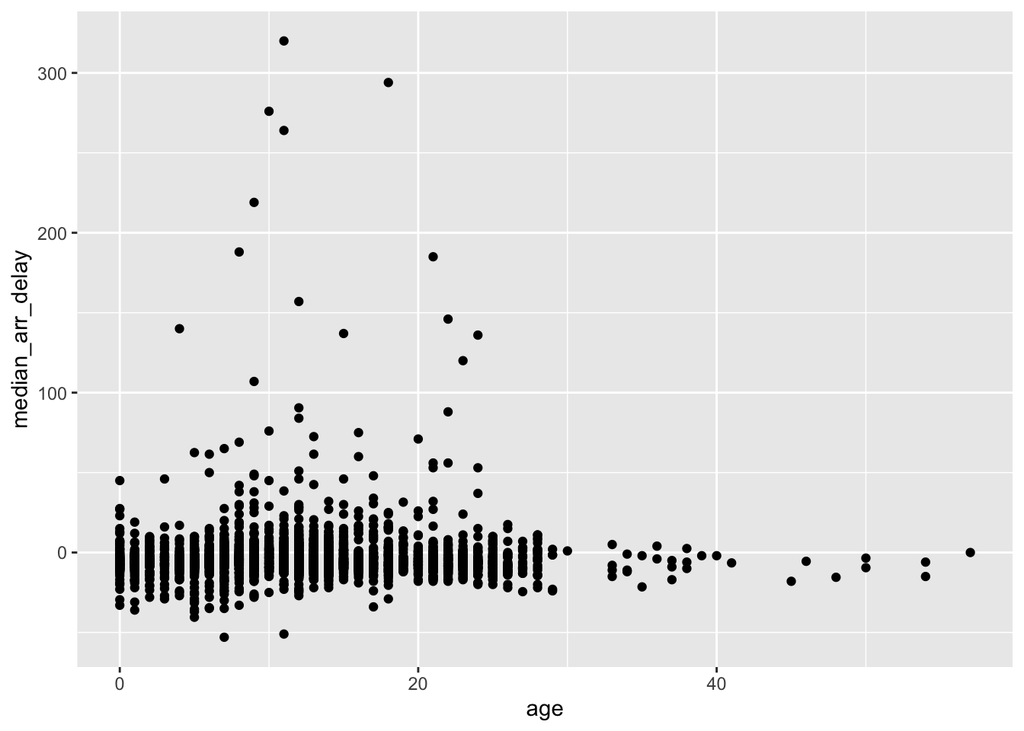

```r
ggplot(delays_by_plane, aes(x = age, y = median_arr_delay)) +
  geom_point()
```

## (FOR LATER) Extra mapping fun

We will try re-creating the visualization below and/or exploring other ways to visualized the flights data spatially. *Note, to view the image in your html, download the “flights_map.png” file and place it in a (new) images subfolder of your STAT_7500 folder.*

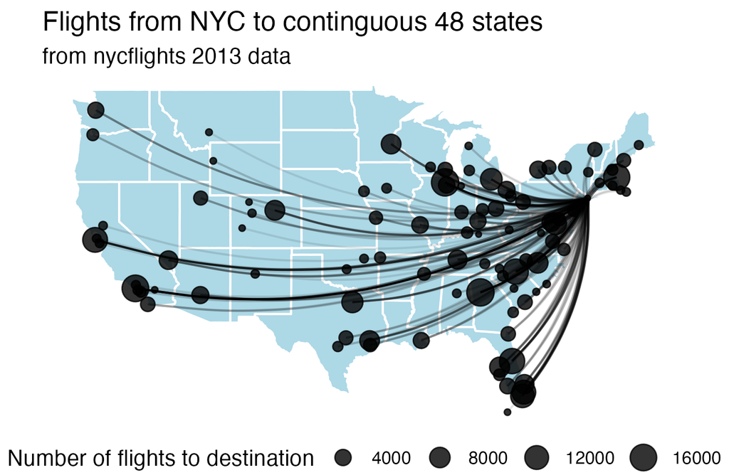

Some starter code is provided below for creating a basic US map.

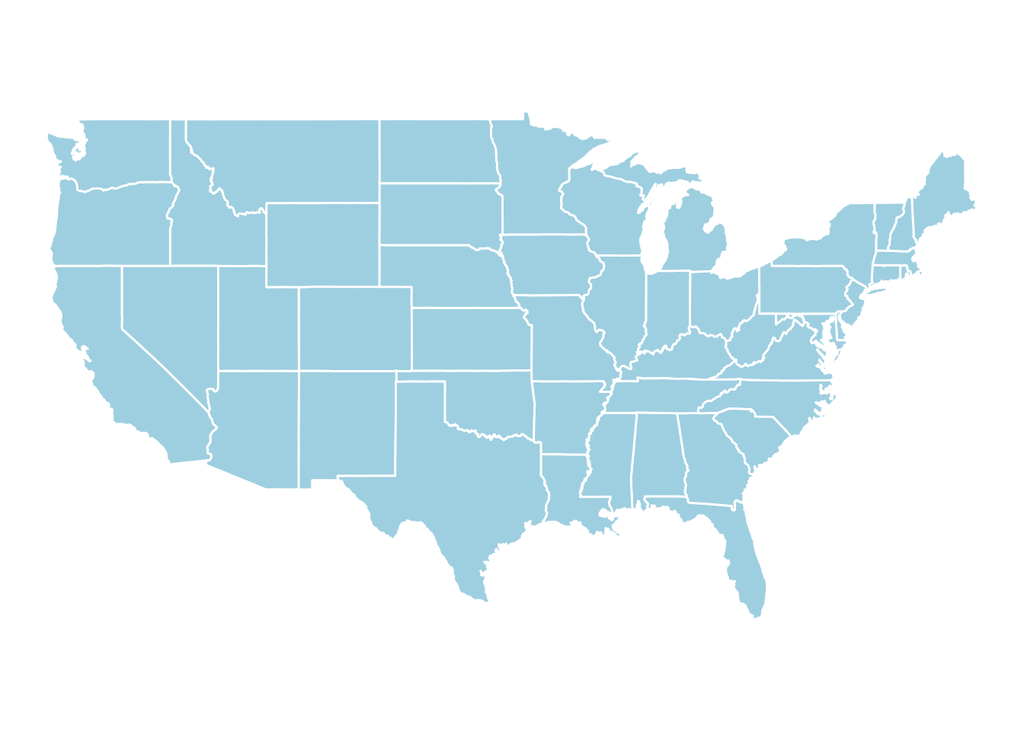

```r
library(maps)
library(mapdata)

state <- map_data("state")

ggplot() +
  geom_polygon(data = state,
               aes(x = long, y = lat, group = group),
               fill = 'lightblue', color = "white") +
  theme_void() +
  coord_fixed(1.3)
```

Adding on the flight trajectories will require some creative data wrangling. You can use a `geom_curve()` layer to create the flight curves; the above plot has `curvature = 0.2`. Note, you can use different datasets and aesthetic mappings in different `geom` layers (see `geom_polygon()` layer above).